# Social Network Analysis

Worksheet 10: ERGMs I

Author

Termeh Shafie

# Introduction

We’re going to follow the ERGM modelling outline:

- specify and estimate model parameters that should govern evolution of network
- simulate other random networks based on specified models
- compare the goodness of fit of observed to model networks.

The following resource is useful for looking up different model terms: [ERGM terms](https://cran.r-project.org/web/packages/ergm/vignettes/ergm-term-crossRef.html).

Note that we now are performing stochastic simulation – in some of the cases, your output will differ slightly from mine and between different runs (you can however use `set.seed()` to get exactly the same results).

## Packages needed

```r
library(statnet) # also loads the ERGM package
library(igraph)
library(ggraph)
library(intergraph)
library(patchwork)
library(networkdata)
```

## Object types

We will be primarily be working with matrix, network and graph objects. Note that `ergm` primarily requires network and adjacency matrices, but since we will be using `ggraph` to visualize networks we also need graph objects. We try to keep it clear here by using suffix *g*, *net* and *mat* to clarify object assignment.

# Florentine marriage network

We start by loading the Florentine marriage network (available in the `statnet` package) and create the adjacency matrix from the loaded network object. This is done with the below code. Note that we have some available node attributes: priorates, totalties, vertex.names and wealth. We’ll be using these attributes later for modeling ERGMs.

```r
data(florentine) # loads flomarriage and flobusiness data
flom_net <- flomarriage # look at the flomarriage network data
flom_mat <- as.matrix(flomarriage)
```

To visualize the network we create a graph object (note that using `geom_node_text` includes the vertex/family names but you can exclude this if you prefer):

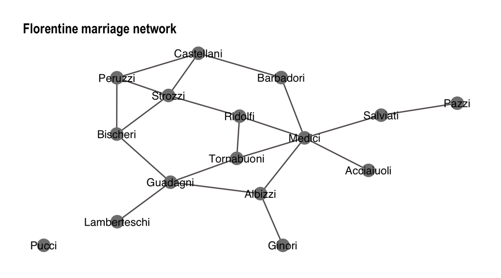

```r
flom_g <- asIgraph(flom_net)
flom_p <- ggraph(flom_g, layout = "stress") +
  geom_edge_link0(edge_colour = "#666060",
                  edge_width = 0.8, edge_alpha = 1) +
  geom_node_point(fill = "#808080", colour = "#808080",
                  size = 7, shape = 21, stroke = 0.9) +
  theme_graph() +
  theme(legend.position = "none") +
  geom_node_text(aes(label = vertex.names), colour = "#000000",
    size = 5, family = "sans") +
  ggtitle("Florentine marriage network")
flom_p
```

## Model 1: Dyadic independence/Bernoulli graph

### Estimation

We begin by specifying a Bernoulli model using the `ergm` function. This is done by only including number of edges as a term in the model (recall from lecture that this implies dyadic independence). Run the model and print out summary of model fit using below code:

```r
flom_mod1 <- ergm(flom_net ~ edges) # fit the model
summary(flom_mod1) # get a summary of model
```

```
Call:
ergm(formula = flom_net ~ edges)

Maximum Likelihood Results:

      Estimate Std. Error MCMC % z value Pr(>|z|)
edges  -1.6094     0.2449      0  -6.571   <1e-04 ***
---
Signif. codes:  0 '***' 0.001 '**' 0.01 '*' 0.05 '.' 0.1 ' ' 1

     Null Deviance: 166.4  on 120  degrees of freedom
 Residual Deviance: 108.1  on 119  degrees of freedom

AIC: 110.1  BIC: 112.9  (Smaller is better. MC Std. Err. = 0)
```

You can also just print the estimated coefficient using only `flom_mod1`.

**Q1**. How can you interpret the parameter estimate?

The log-odds of any tie occurring is:
$$-1.609 \times \textrm{change in the number of ties} = -1.609 \times 1$$
for all ties, since the addition of any tie to the network changes the number of ties by 1. Corresponding probability is:
$$\frac{\exp{(-1.609)}}{1+\exp{(-1.609)}}=0.1667$$
which is what you would expect, since there are 20/120 ties.

## Model 2: Transitivity effect added

### Estimation

Next, we add a term the number of completed triangles/triads (which would indicate **transitivity**).

```r
set.seed(1) #include if you want the same results shown here
flom_mod2 <- ergm(flom_net ~ edges + triangle)
summary(flom_mod2)
```

```
Call:
ergm(formula = flom_net ~ edges + triangle)

Monte Carlo Maximum Likelihood Results:

         Estimate Std. Error MCMC % z value Pr(>|z|)
edges     -1.6913     0.3219      0  -5.254   <1e-04 ***
triangle   0.1808     0.5567      0   0.325    0.745
---
Signif. codes:  0 '***' 0.001 '**' 0.01 '*' 0.05 '.' 0.1 ' ' 1

     Null Deviance: 166.4  on 120  degrees of freedom
 Residual Deviance: 108.1  on 118  degrees of freedom

AIC: 112.1  BIC: 117.6  (Smaller is better. MC Std. Err. = 0.01061)
```

**Q2** How can you interpret the parameter estimates?

**Q3** What do the parameter estimates tell us about the configurations specified in the model?

Conditional log-odds of two actors forming a tie is:

- $-1.6913\times$ change in the number of ties + $0.1808 \times$ change in number of triangles
- if the tie will not add any triangles to the network, its log-odds is: -1.6913
- if it will add one triangle to the network, its log-odds is: -1.6913 + 0.1808
- if it will add two triangles to the network, its log-odds is: -1.6913 + 0.1808 $\times$ 2

### MCMC diagnostics

You can use `mcmc.diagnostics(flom_mod2)` to observe the behavior of the MCMC estimation algorithm and check for degeneracy. What you want to see in the MCMC diagnostics: the MCMC sample statistics varying randomly around the observed values at each step in the trace plots (which means the chain is mixing well) and the difference between the observed and simulated values of the sample statistics should have a roughly bell-shaped distribution, centered at 0 (which means no difference):

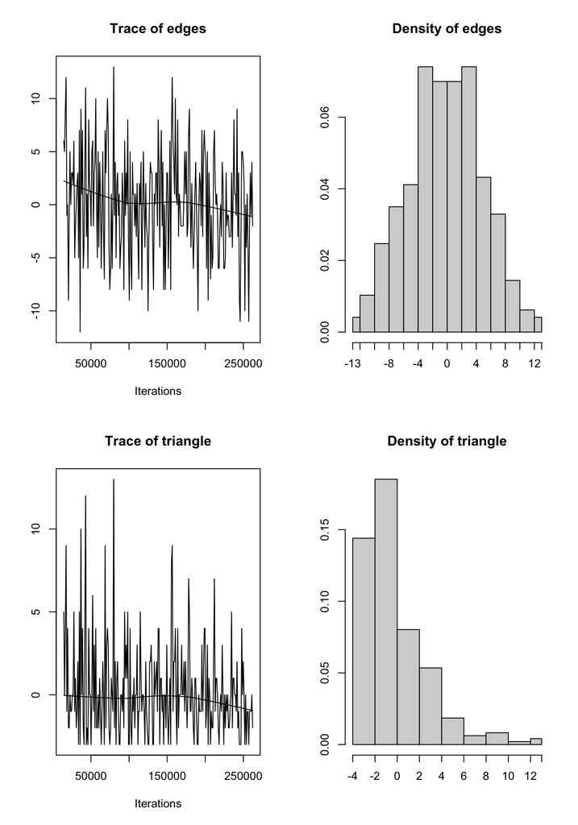

```
Sample statistics summary:

Iterations = 14336:262144
Thinning interval = 1024
Number of chains = 1
Sample size per chain = 243

1. Empirical mean and standard deviation for each variable,
   plus standard error of the mean:

           Mean    SD Naive SE Time-series SE
edges    0.2058 4.957   0.3180         0.3180
triangle 0.2222 2.866   0.1839         0.1839

2. Quantiles for each variable:

         2.5% 25% 50% 75% 97.5%
edges      -9  -3   0   4  9.95
triangle   -3  -2   0   1  7.95


Are sample statistics significantly different from observed?
               edges  triangle    (Omni)
diff.      0.2057613 0.2222222        NA
test stat. 0.6471018 1.2086209 1.6694087
P-val.     0.5175661 0.2268085 0.4367585

Sample statistics cross-correlations:
             edges  triangle
edges    1.0000000 0.7771561
triangle 0.7771561 1.0000000

Sample statistics auto-correlation:
Chain 1
                edges    triangle
Lag 0     1.000000000  1.00000000
Lag 1024  0.056425983 -0.04043396
Lag 2048  0.006273791  0.01940035
Lag 3072 -0.051649675 -0.02455474
Lag 4096 -0.034487041  0.02913158
```

[output cut: 8 more lines]

```
   edges triangle
1.458524 1.483872

Individual P-values (lower = worse):
    edges  triangle
0.1446962 0.1378428
Joint P-value (lower = worse):  0.1011719

Note: MCMC diagnostics shown here are from the last round of
  simulation, prior to computation of final parameter estimates.
  Because the final estimates are refinements of those used for this
  simulation run, these diagnostics may understate model performance.
  To directly assess the performance of the final model on in-model
  statistics, please use the GOF command: gof(ergmFitObject,
  GOF=~model).
```

```r
mcmc.diagnostics(flom_mod2, center = TRUE)
```

**Q4** How would you interpret these results?

### Simulation

When we have estimated the coefficients of an ERGM, we have defined a probability distribution across all networks of the same size. If the model is a good fit to the observed data, networks drawn from this distribution resemble the observed data. To draw networks from this distribution we use the `simulate()` function. We draw ten networks from the specified model and use the below command to get a summary of what the network statistics `edges` and `triangles` are for each of the ten sampled networks.

```r
flom_mod2.sim <- simulate(flom_mod2, nsim = 10)
summary(flom_mod2.sim)
```

```
List of  10  Networks
Model: flom_net ~ edges + triangle
Reference: ~Bernoulli
Constraints: ~. ~. - observed
Stored network statistics:
      edges triangle
 [1,]    16        3
 [2,]    26        7
 [3,]    18        1
 [4,]    17        1
 [5,]    22        1
 [6,]    18        1
 [7,]    11        1
 [8,]    22        4
 [9,]    20        3
[10,]    26        6
attr(,"monitored")
[1] FALSE FALSE
```

[output not shown]

This should give you a list over the ten networks and columns representing how many edges and triangles are apparent in each simulated case. Since you have listed all the simulated networks, you can simply call each one of them individually. For example, in the below, we call simulated networks 1 and 2:

```r
flom_mod2.sim[[1]]
flom_mod2.sim[[2]]
```

You can also choose one of the networks to visualize, below is an example for the tenth, i.e. last on the list of, simulated network:

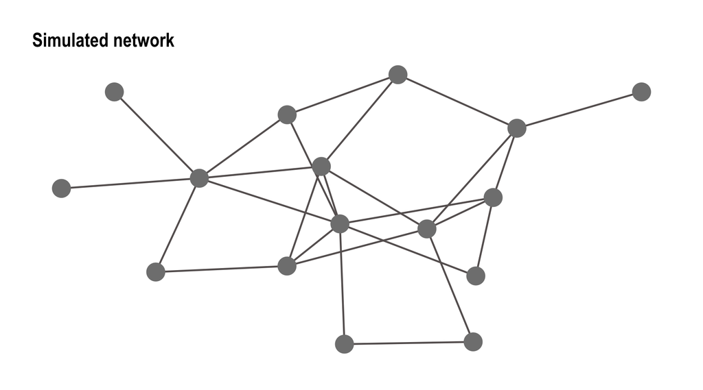

```r
flom.sim_g <-asIgraph(flom_mod2.sim[[10]])
flom.sim_p <- ggraph(flom.sim_g, layout = "stress") +
  geom_edge_link0(edge_colour = "#666060",
                  edge_width = 0.8, edge_alpha = 1) +
  geom_node_point(fill = "#808080", colour = "#808080",
                  size = 7, shape = 21, stroke = 0.9) +
  theme_graph() +
  theme(legend.position = "none") +
  ggtitle("Simulated network")
flom.sim_p
```

These simulations are crucial for examining the goodness of fit which we will do next.

### 3. Goodness of Fit

The MCMC algorithm draws a dyad at random at each step, and evaluates the probability of a tie from the perspective of these two nodes. That probability is governed by the ergm-terms specified in the model, and the current estimates of the coefficients on these terms. Once the estimates converge, simulations from the model will produce networks that are centered on the observed model statistics i.e. those we control for (otherwise it is a sign that something has gone wrong in the estimation process). The networks will also have other emergent global properties that are not represented by explicit terms in the model. Thus, goodness of fit can be done in two ways, where the first is to be preferred:

- evaluate the fit to the specified terms in the model (done by default)
- evaluate the fit of terms not specified in the model to emergent global network properties

If the first does not indicate something off in the estimation process, you can use the second where three terms that can be used to evaluate the fit to emergent global network properties:

1. the node level (degree)
2. the edge level (esp: edgewise share partners)
3. the dyad level (geodesic distances)

We check now whether the specified model above fits the observed data and how well it reproduces it. We do this by choosing a network statistic (that is not specified in the model), and comparing the value of this statistic to the distribution of values we get in simulated networks from our model. We use the `gof()` function.

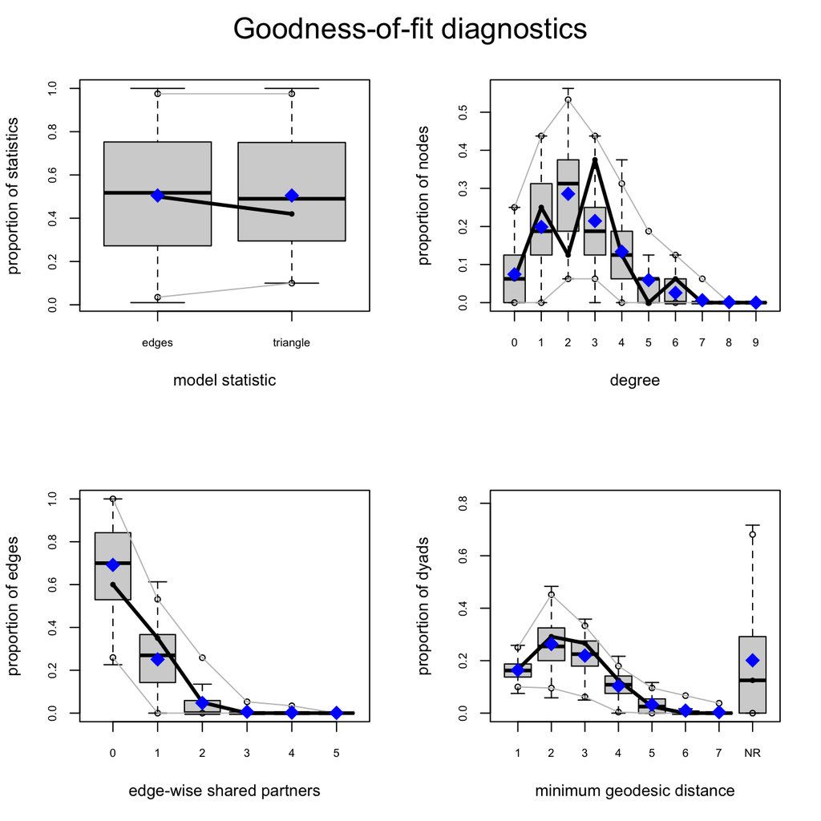

```r
flom_mod2.gof <- gof(flom_mod2) # this will produce 4 plots
par(mfrow=c(2,2)) # figure orientation with 2 rows and 2 columns
plot(flom_mod2.gof) # gof plots
```

To get an output containing the summary of the gof:

```r
flom_mod2.gof # summary output of gof
```

**Q5** How would you interpret the goodness of fit here?

# Lazega’s lawyers (from lecture)

We will use the same subset of this network as in the previous lab: we want to check whether or not the *partners* of the firm more frequently work together with other partners having the same practice. We import the data as a graph object from the `networkdata` package:

```r
data("law_cowork")
```

We then create an adjacency matrix from the directed graph for the first 36 lawyers in the network corresponding to the partners of the firm (see attribute ‘status’). To test homophily now, we only consider the reciprocal ties so we need to symmetrize the matrix to create and undirected graph:

```r
law_mat_cwdir <- as_adjacency_matrix(law_cowork, sparse = FALSE)
law_mat_cwdir <- law_mat_cwdir[1:36,1:36]
law_mat_cw <- (law_mat_cwdir == t(law_mat_cwdir) & law_mat_cwdir ==1) + 0
```

Next we save the binary attribute ‘practice’ (1 = litigation, 2 = corporate) from the graph object as a vector, which is then in turn converted into a data frame (again only for the first 36 lawyers who are partners):

```r
law_attr.pract <- vertex_attr(law_cowork)$pract[1:36] - 1
```

Since observed attribute values are 1/2, we subtract 1 to get a 0/1 variable which is easier to interpret in an ERGM context.

We create a network object and add the node attribute ‘practice’:

```r
law_net <- as.network(law_mat_cw, directed = FALSE)
law_net %v% "practice" <- law_attr.pract
law_net
```

```
 Network attributes:
  vertices = 36
  directed = FALSE
  hyper = FALSE
  loops = FALSE
  multiple = FALSE
  bipartite = FALSE
  total edges= 115
    missing edges= 0
    non-missing edges= 115

 Vertex attribute names:
    practice vertex.names

No edge attributes
```

## Model 1: homophily and clustering

### Estimation

We are interested in running an ERGM with the following statistics (as done during lecture)

- nodecov(“practice”)
- match(“practice”)
- gwesp(decay = 0.693)

**Q6** Can you recall what these statistics represent? To run the ERGM:

```r
law_mod1 <- ergm(law_net ~ edges
  + nodecov("practice") + match("practice")
  + gwesp(0.693, fixed = TRUE)
)
summary(law_mod1)
```

```
Call:
ergm(formula = law_net ~ edges + nodecov("practice") + match("practice") +
    gwesp(0.693, fixed = TRUE))

Monte Carlo Maximum Likelihood Results:

                   Estimate Std. Error MCMC % z value Pr(>|z|)
edges              -4.40585    0.32293      0 -13.643  < 1e-04 ***
nodecov.practice    0.17540    0.07822      0   2.242 0.024942 *
nodematch.practice  0.61329    0.17500      0   3.504 0.000458 ***
gwesp.fixed.0.693   1.15219    0.15967      0   7.216  < 1e-04 ***
---
Signif. codes:  0 '***' 0.001 '**' 0.01 '*' 0.05 '.' 0.1 ' ' 1

     Null Deviance: 873.4  on 630  degrees of freedom
 Residual Deviance: 502.8  on 626  degrees of freedom

AIC: 510.8  BIC: 528.6  (Smaller is better. MC Std. Err. = 0.3076)
```

See lecture slides for the interpretation of these coefficients.

### MCMC diagnostics

Check the model by running MCMC diagnostics to observe what is happening with the simulation algorithm:

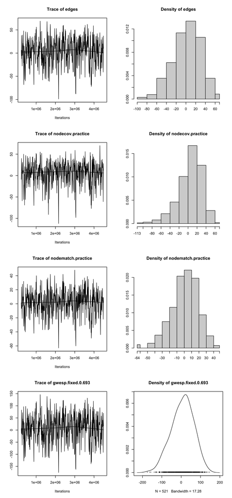

```
Sample statistics summary:

Iterations = 229376:4489216
Thinning interval = 8192
Number of chains = 1
Sample size per chain = 521

1. Empirical mean and standard deviation for each variable,
   plus standard error of the mean:

                    Mean    SD Naive SE Time-series SE
edges              2.873 28.97   1.2692          1.686
nodecov.practice   5.472 26.86   1.1766          1.330
nodematch.practice 1.816 17.76   0.7782          1.105
gwesp.fixed.0.693  6.493 57.22   2.5071          3.240

2. Quantiles for each variable:

                     2.5%    25%   50%   75% 97.5%
edges               -56.0 -15.00  6.00 23.00  53.0
nodecov.practice    -59.0 -10.00 10.00 24.00  48.0
nodematch.practice  -37.0  -9.00  3.00 14.00  33.0
gwesp.fixed.0.693  -110.6 -30.89 12.37 45.45 108.6


Are sample statistics significantly different from observed?
                edges nodecov.practice nodematch.practice gwesp.fixed.0.693
diff.      2.87332054     5.472169e+00          1.8157390        6.49349193
test stat. 1.70443427     4.114483e+00          1.6431992        2.00438393
P-val.     0.08829999     3.880485e-05          0.1003417        0.04502895
                 (Omni)
diff.                NA
test stat. 3.322843e+01
P-val.     1.994933e-06

Sample statistics cross-correlations:
                       edges nodecov.practice nodematch.practice
edges              1.0000000        0.8698784          0.9464560
nodecov.practice   0.8698784        1.0000000          0.8320838
nodematch.practice 0.9464560        0.8320838          1.0000000
```

[output cut: 23 more lines]

```
             edges   nodecov.practice nodematch.practice  gwesp.fixed.0.693
        -0.8457193         -0.7756416         -0.7844341         -0.9158578

Individual P-values (lower = worse):
             edges   nodecov.practice nodematch.practice  gwesp.fixed.0.693
         0.3977094          0.4379606          0.4327855          0.3597415
Joint P-value (lower = worse):  0.9021505

Note: MCMC diagnostics shown here are from the last round of
  simulation, prior to computation of final parameter estimates.
  Because the final estimates are refinements of those used for this
  simulation run, these diagnostics may understate model performance.
  To directly assess the performance of the final model on in-model
  statistics, please use the GOF command: gof(ergmFitObject,
  GOF=~model).
```

```r
mcmc.diagnostics(law_mod1, center = TRUE)
```

**Q6** Do you see any problems with model degeneracy here? Is the estimation process working as it should?

### Goodness of Fit

Goodness of fit can be checked as done earlier:

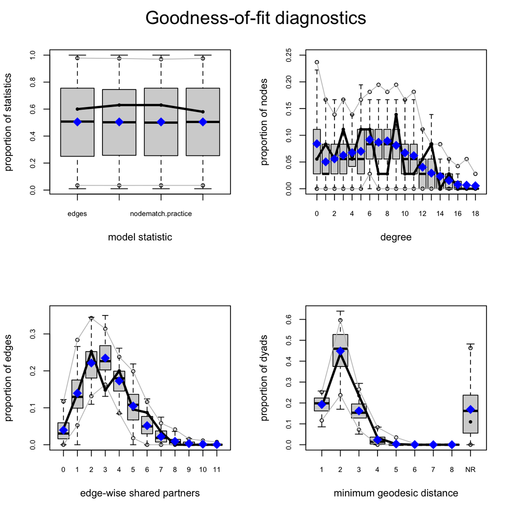

```r
law_mod1.gof <- gof(law_mod1) # this will produce 4 plots
par(mfrow = c(2, 2)) # figure orientation with 2 rows and 2 columns
plot(law_mod1.gof)
```

Note that you should not use `esp` to assess goodness of fit since it was explicitly modeled via the `gwesp` term in the specified model.

# Knecht’s Friendship Network

For the last part, we will fir an ERGM to a directed network to check for reciprocity. We use a friendship network (Knecht,2008) which can be loaded using the `networkdata` package. You can read about the network by typing `?knecht`. Note that the network is longitudinal and observed over four time periods. We will here focus on the last time period. To load the wave 4 data and to visualize it:

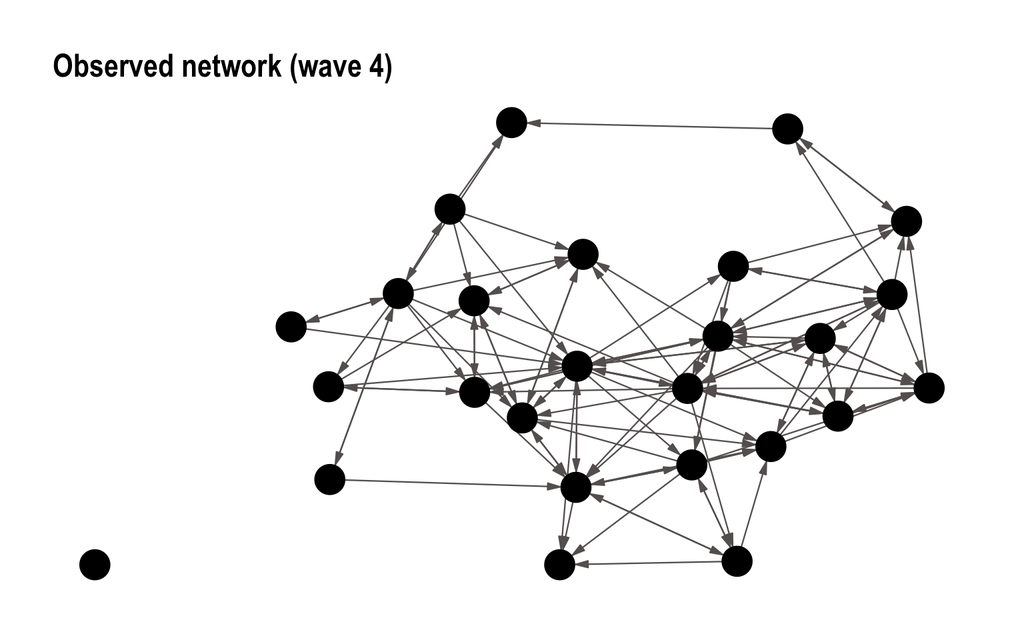

```r
data("knecht")
knecht4_g <- knecht[[4]]
knecht4_p <- ggraph(knecht4_g, layout = "stress") +
  geom_edge_link(edge_colour = "#666060", end_cap = circle(9,"pt"),
                         n = 2, edge_width = 0.4, edge_alpha = 1,
                         arrow = arrow(angle = 15,
                         length = unit(0.1, "inches"),
                         ends = "last", type = "closed"))  +
  geom_node_point(fill = "#000000", colour = "#000000",
                  size = 7, shape = 21, stroke = 0.9) +
  theme_graph() +
  theme(legend.position = "none") +
  ggtitle("Observed network (wave 4)")
knecht4_p
```

Next we create the network object to fit ERGMs:

```r
  # to create network objects
knecht4_net <- asNetwork(knecht[[4]])
```